# Clean Baseline Scores

Author

Yan Zhu

Published

June 6, 2024

## Introduction

This file is aim to clean the baesline score

**Note:** The data file is from the CSV file which generated from Data Anonymization.Rmd

[output not shown]

## Scores

### DERS

**Difficulties in Emotion Regulation Scale:** It is a scale used to assess an individual’s difficulty regulating emotions and is commonly used in research and clinical practice in the fields of psychology and mental health. The DERS is typically scored based on respondent responses, with higher scores indicating greater difficulty with emotion regulation.

- ders1: (Awareness) I pay attention to how I feel
- ders2: (Clarity) I have no idea how I am feeling
- ders3: (Clarity) I have difficulty making sense out of my feelings
- ders4: (Awareness) I am attentive to my feelings
- ders5: (Clarity) I am confused about how I feel
- ders6: (Awareness) When I am upset, I acknowledge my emotions
- ders7: (Nonacceptance) When I am upset, I become embarrassed for feeling that way
- ders8: (Goals) When I am upset, I have difficulty getting work done.
- ders9: (Impulse) When I am upset, I become out of control
- ders10: (Strategies) When I am upset, I believe that I will remain that way for a long time
- ders11: (Strategies) When I am upset, I believe that I’ll end up feeling very depressed
- ders12: (Goals) When I am upset, I have difficulty focusing on other things
- ders13: (Nonacceptance) When I am upset, I feel ashamed with myself for feeling that way
- ders14: (Nonacceptance) When I am upset, I feel guilty for feeling that way
- ders15: (Goals) When I am upset, I have difficulty concentrating
- ders16: (Impulse) When I am upset, I have difficulty controlling my behaviors
- ders17: (Strategies) When I am upset, I believe that wallowing in it is all I can do
- ders18: (Impulse) When I am upset, I lose control over my behaviors

[Victor, S. E., & Klonsky, E. D. (2016). Validation of a brief version of the difficulties in emotion regulation scale (DERS-18) in five samples. Journal of psychopathology and Behavioral Assessment, 38(4), 582-589.](https://www2.psych.ubc.ca/~klonsky/publications/DERS18.pdf)

```r
ders <- read_csv("/Users/yan/Desktop/sample_code/ESM/1_anonymization/anonymous_baseline.csv", show_col_types = FALSE) %>%
  select(random_id, ders1, ders2, ders3, ders4, ders5, ders6, ders7, ders8, ders9, ders10, ders11, ders12, ders13, ders14, ders15, ders16, ders17, ders18)

describe(ders)
```

```
          vars   n      mean        sd median   trimmed       mad    min    max
random_id    1 254 537970.42 259373.54 531265 534569.95 311967.21 102743 998678
ders1        2 254      2.02      0.85      2      1.94      0.00      1      5
ders2        3 254      2.46      0.89      2      2.42      1.48      1      5
ders3        4 254      2.74      0.90      3      2.75      1.48      1      5
ders4        5 254      2.31      0.83      2      2.27      1.48      1      5
ders5        6 254      2.81      0.98      3      2.84      1.48      1      5
ders6        7 254      2.26      0.92      2      2.19      1.48      1      5
ders7        8 254      2.70      1.07      3      2.69      1.48      1      5
ders8        9 254      3.62      0.99      4      3.68      1.48      1      5
ders9       10 254      1.98      0.97      2      1.86      1.48      1      5
ders10      11 254      2.43      1.05      2      2.36      1.48      1      5
ders11      12 254      2.32      1.17      2      2.21      1.48      1      5
ders12      13 254      3.46      1.08      3      3.49      1.48      1      5
ders13      14 254      2.57      1.12      2      2.53      1.48      1      5
ders14      15 254      2.61      1.16      3      2.56      1.48      1      5
ders15      16 254      3.52      1.05      4      3.57      1.48      1      5
ders16      17 254      2.13      1.02      2      2.02      1.48      1      5
ders17      18 254      2.21      0.96      2      2.13      1.48      1      5
ders18      19 254      1.76      0.88      2      1.62      1.48      1      5
           range  skew kurtosis       se
random_id 895935  0.09    -1.11 16274.54
ders1          4  0.78     0.63     0.05
ders2          4  0.31     0.05     0.06
ders3          4  0.07    -0.17     0.06
ders4          4  0.40    -0.13     0.05
ders5          4  0.01    -0.45     0.06
ders6          4  0.51    -0.11     0.06
ders7          4  0.16    -0.73     0.07
ders8          4 -0.38    -0.40     0.06
ders9          4  1.02     0.89     0.06
ders10         4  0.47    -0.40     0.07
ders11         4  0.57    -0.58     0.07
ders12         4 -0.16    -0.82     0.07
ders13         4  0.33    -0.69     0.07
ders14         4  0.29    -0.79     0.07
ders15         4 -0.49    -0.33     0.07
ders16         4  0.70    -0.15     0.06
ders17         4  0.57     0.00     0.06
ders18         4  1.30     1.84     0.06
```

```r
# Check Cronbach's alpha
ders_key = c('ders1', 'ders2', 'ders3', 'ders4', 'ders5', 'ders6', 'ders7', 'ders8', 'ders9', 'ders10', 'ders11', 'ders12', 'ders13', 'ders14', 'ders15', 'ders16', 'ders17', 'ders18')

ders_alpha <- psych::alpha(ders[, ders_key], keys = c('ders1', 'ders4', 'ders6')) # 0.86
ders_alpha_table <- kable(ders_alpha$alpha, caption = "Cronbach's Alpha for DERS")
ders_alpha_table
```

Cronbach’s Alpha for DERS

|  | raw_alpha | std.alpha | G6(smc) | average_r | S/N | alpha se | var.r | med.r |
| --- | --- | --- | --- | --- | --- | --- | --- | --- |
| ders1- | 0.8751458 | 0.8955414 | 0.9307609 | 0.3352409 | 8.573174 | 0.0105306 | 0.0293884 | 0.3337483 |
| ders2 | 0.8613413 | 0.8890585 | 0.9295933 | 0.3203740 | 8.013758 | 0.0117295 | 0.0348581 | 0.3321055 |
| ders3 | 0.8589581 | 0.8879952 | 0.9281910 | 0.3180411 | 7.928187 | 0.0118967 | 0.0347989 | 0.3288824 |
| ders4- | 0.8788376 | 0.8917476 | 0.9293611 | 0.3264036 | 8.237666 | 0.0103649 | 0.0326102 | 0.3288824 |
| ders5 | 0.8550490 | 0.8851211 | 0.9265454 | 0.3118751 | 7.704818 | 0.0122059 | 0.0347048 | 0.3123870 |
| ders6- | 0.8744619 | 0.8979070 | 0.9332895 | 0.3409573 | 8.794989 | 0.0105313 | 0.0271855 | 0.3337483 |
| ders7 | 0.8536116 | 0.8865688 | 0.9263797 | 0.3149557 | 7.815914 | 0.0123198 | 0.0328653 | 0.3252704 |
| ders8 | 0.8500598 | 0.8868379 | 0.9263452 | 0.3155341 | 7.836884 | 0.0126101 | 0.0310986 | 0.3123870 |
| ders9 | 0.8498517 | 0.8862647 | 0.9257953 | 0.3143045 | 7.792347 | 0.0125910 | 0.0309907 | 0.3094450 |
| ders10 | 0.8480443 | 0.8837229 | 0.9258598 | 0.3089472 | 7.600147 | 0.0128451 | 0.0324661 | 0.3082442 |
| ders11 | 0.8472813 | 0.8819420 | 0.9245477 | 0.3052835 | 7.470415 | 0.0129663 | 0.0327037 | 0.3064894 |
| ders12 | 0.8473539 | 0.8848672 | 0.9250127 | 0.3113400 | 7.685623 | 0.0128817 | 0.0308295 | 0.3094450 |
| ders13 | 0.8491192 | 0.8840082 | 0.9229254 | 0.3095408 | 7.621296 | 0.0127409 | 0.0315186 | 0.3198083 |
| ders14 | 0.8490846 | 0.8841427 | 0.9234105 | 0.3098214 | 7.631307 | 0.0127481 | 0.0315930 | 0.3168663 |
| ders15 | 0.8468540 | 0.8850199 | 0.9234800 | 0.3116616 | 7.697154 | 0.0129030 | 0.0302579 | 0.3071758 |
| ders16 | 0.8527726 | 0.8877407 | 0.9264656 | 0.3174868 | 7.907944 | 0.0123390 | 0.0320508 | 0.3252704 |
| ders17 | 0.8519092 | 0.8847848 | 0.9271317 | 0.3111666 | 7.679408 | 0.0124916 | 0.0339472 | 0.3071758 |
| ders18 | 0.8527061 | 0.8855017 | 0.9246827 | 0.3126802 | 7.733755 | 0.0123720 | 0.0326295 | 0.3266701 |

```r
# Create a DataFrame to save composite scores from different survey.
baseline <- ders %>% select(random_id)

# Calculate the composite for DERS
baseline$ders_composite = varScore(ders,
                  Forward= c('ders2', 'ders3', 'ders5', 'ders7',
                             'ders8', 'ders9', 'ders10', 'ders11',
                             'ders12', 'ders13', 'ders14', 'ders15',
                             'ders16', 'ders17', 'ders18'),
                  Reverse= c('ders1', 'ders4', 'ders6'),
                  Range=c(1, 5),
                  Prorate=T) / 18

baseline$ders_composite <- round(baseline$ders_composite, 2)
```

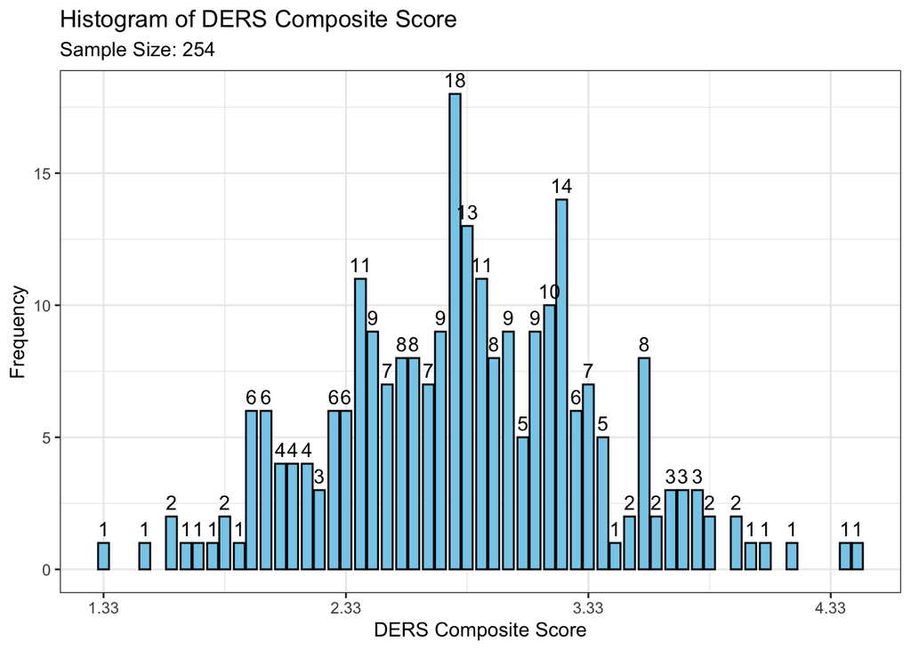

```r
ggplot(baseline, aes(x = ders_composite)) +
  geom_bar(fill = "skyblue", color = "black") +
  geom_text(stat = "count", aes(label = after_stat(count)), vjust = -0.5) +
  scale_x_continuous(breaks = seq(min(baseline$ders_composite), max(baseline$ders_composite), by = 1)) +
  labs(x = "DERS Composite Score",
       y = "Frequency",
       title = "Histogram of DERS Composite Score",
       subtitle = paste("Sample Size:", nrow(baseline))) +
  theme(plot.subtitle = element_text(size = 10)) +
  theme_bw()
```